# Connectivity - EI

J. Jung, R. Bouet, H. Catenoix, A. Montavont, J. Isnard, S. Boulogne, M. Guénot, P. Ryvlin, S. Rheims (2022) The neural bases of ictal hypoxemia during Temporal Lobe Seizures. Humain Brain Mapping

Focal seizures originating from the temporal lobe are commonly associated with peri-ictal hypoxemia (PIH). During the course of temporal lobe seizures, epileptic discharges often spread within various parts of the temporal lobe but also possibly insula and frontal lobe. The link between spatial propagation of the seizure discharges and PIH is still unclear. Methods : The present study investigates the involvement of several brain structures including medial temporal structures, temporal pole, anterior insula and frontal cortex in the occurrence of PIH. Using quantitative indices obtained during SEEG (stereoencephalography) recordings in 38 patients, we evaluated the epileptogenicity, the spatial propagation and functional connectivity between those structures during seizures leading to PIH.

Key words:  
GLM; Gamma distribution; Wilcoxon; LRT; parallel

# EI

## Load datas

Here we extract datas from .txt file.

```r
file_path = "/Users/romain/Study/Rheins/Desaturation_Coherence/Datas_raw/EI/EI_JJ.txt"
datas <- read.table(file_path,
                    dec = ".",
                    header = TRUE)

datas %>%
  gather(key = "Structure",
         value = "EI",
         -Patname, -desat) %>%
  drop_na() %>%
  mutate(Structure = case_when(Structure == "hippoc_ant" ~ "Ant Hippo",
                               Structure == "hippoc_post" ~ "Post Hippo",
                               Structure == "amygdale" ~ "Amygdala",
                               Structure == "cing_ant" ~ "ACC",
                               Structure == "insula_ant" ~ "Ant Insula",
                               Structure == "insula_post" ~ "Post Insula",
                               Structure == "CTL" ~ "Lat Temp",
                               Structure == "frontal_lat" ~ "Lat Front",
                               Structure == "COF" ~ "OFC",
                               Structure == "pole_temp" ~ "Pole Temp")) %>%
  filter(Structure != "Lat Front" & Structure != "Post Insula" & Structure != "Post Hippo") %>%
  mutate(Structure = factor(Structure, levels = c("Ant Hippo", "Amygdala", "Pole Temp", "Lat Temp", "Ant Insula", "OFC", "ACC"))) %>%
  mutate(Structure = as.factor(Structure)) %>%
  data.frame() -> datas



datas %>%
  dplyr::select(-Patname) %>%
  gtsummary::tbl_summary(by = "Structure") %>%
  gtsummary::add_p()
```

| **Characteristic** | **Ant Hippo**, N = 37<sup>1</sup> | **Amygdala**, N = 31<sup>1</sup> | **Pole Temp**, N = 33<sup>1</sup> | **Lat Temp**, N = 37<sup>1</sup> | **Ant Insula**, N = 28<sup>1</sup> | **OFC**, N = 21<sup>1</sup> | **ACC**, N = 10<sup>1</sup> | **p-value**<sup>2</sup> |
| --- | --- | --- | --- | --- | --- | --- | --- | --- |
| desat |  |  |  |  |  |  |  | >0.9 |
| N | 19 (51%) | 16 (52%) | 17 (52%) | 19 (51%) | 14 (50%) | 12 (57%) | 6 (60%) |  |
| Y | 18 (49%) | 15 (48%) | 16 (48%) | 18 (49%) | 14 (50%) | 9 (43%) | 4 (40%) |  |
| EI | 0.67 (0.11, 1.00) | 0.03 (0.00, 0.10) | 0.01 (0.00, 0.14) | 0.00 (0.00, 0.02) | 0.00 (0.00, 0.03) | 0.00 (0.00, 0.00) | 0.00 (0.00, 0.00) | <0.001 |

<sup>1</sup> n (%); Median (IQR)  
<sup>2</sup> Fisher's exact test; Kruskal-Wallis rank sum test

## Display

To explore behaviour raw datas.

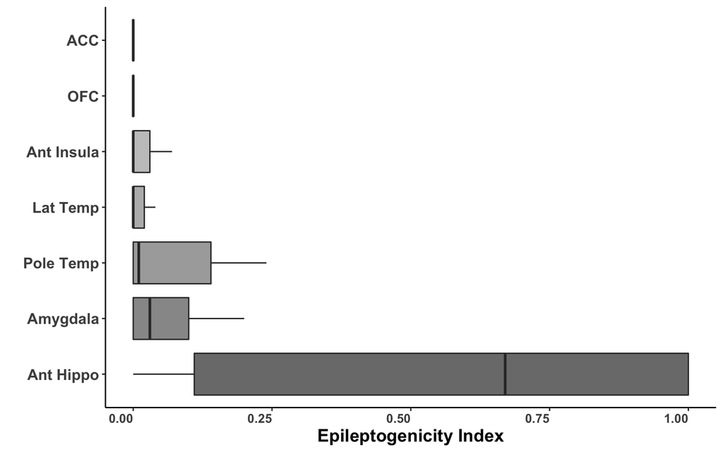

```r
datas %>%
  ggplot(aes(x = Structure, y = EI, fill = Structure)) +
    geom_boxplot(alpha = 0.7, outlier.shape = NA) +
    coord_cartesian(ylim=c(-0.001, 0.03)) +
  scale_fill_grey() +
  theme_classic() +
  coord_flip() +
  theme(legend.position = "none",
        axis.title.x = element_text(size = 14, face = "bold"),
        axis.text.x = element_text(face = "bold", size = 10, angle = 0, hjust = 1),
        axis.text.y = element_text(face = "bold", size = 12, angle = 0, hjust = 1)) +
  labs(x = "",
       y = "Epileptogenicity Index")
```

## Stat

EI is value define between 0 and 1, so binomial distribution.  
Some structures have only O values. So we couldn’t use glm models.  
Here we use Wilcoxon test to compare EI for all combinaison of structure.

```r
test.w.struct <- data.frame(Structure.A = character(),
                            Structure.B = character(),
                            p.value   = double())

all.comb.struct <- combn(unique(datas$Structure), 2, simplify = TRUE)

for (xi.struct in c(1:dim(all.comb.struct)[2])){

  test.w.tamp <- wilcox.test(filter(datas, Structure == all.comb.struct[1, xi.struct])$EI,
                             filter(datas, Structure == all.comb.struct[2, xi.struct])$EI,
                             alternative = "greater",
                             paired = FALSE,
                             exact = TRUE,
                             correct = FALSE,
                             conf.int = TRUE)

  test.w.struct %>%
    add_row(Structure.A = all.comb.struct[1, xi.struct],
            Structure.B = all.comb.struct[2, xi.struct],
            p.value = round(test.w.tamp$p.value, 8)) -> test.w.struct
}

test.w.struct
```

```
##    Structure.A Structure.B    p.value
## 1     Amygdala   Ant Hippo 0.99987336
## 2     Amygdala  Ant Insula 0.01062040
## 3     Amygdala         OFC 0.00015239
## 4     Amygdala    Lat Temp 0.01295886
## 5     Amygdala         ACC 0.00080585
## 6     Amygdala   Pole Temp 0.30151635
## 7    Ant Hippo  Ant Insula 0.00000056
## 8    Ant Hippo         OFC 0.00000027
## 9    Ant Hippo    Lat Temp 0.00000021
## 10   Ant Hippo         ACC 0.00003633
## 11   Ant Hippo   Pole Temp 0.00009711
## 12  Ant Insula         OFC 0.04115669
## 13  Ant Insula    Lat Temp 0.54673612
## 14  Ant Insula         ACC 0.02380959
## 15  Ant Insula   Pole Temp 0.94258752
## 16         OFC    Lat Temp 0.96304841
## 17         OFC         ACC 0.17886242
## 18         OFC   Pole Temp 0.99751702
## 19    Lat Temp         ACC 0.02140391
## 20    Lat Temp   Pole Temp 0.93243438
## 21         ACC   Pole Temp 0.99504678
```

# TF

## Load datas

```r
filename.TF <- "/Users/romain/Study/Rheins/Desaturation_Coherence/Datas_preprocessed/Mesures/extract_tf_sample_TF_sampl_corrige_doubleCrise_TF_sampl.txt"

filename.Desat <- "/Users/romain/Study/Rheins/Desaturation_Coherence/Datas_preprocessed/Mesures/Desat_parametres.txt"

datas.TF    <- read.table(filename.TF, header = TRUE)
datas.Desat <- read.table(filename.Desat, header = TRUE)


datas.TF %>%
  filter(Win != "BASELINE" & Win != "pre_ONSET" & Win!= "POST_SEIZURE") %>%
  filter(Structure != "frontallat" & Structure != "insulapost" & Structure != "hippocpost") %>%
  mutate(Win = factor(Win, levels = c("ONSET", "MID_SEIZURE", "END_SEIZURE"))) %>%
  drop_na(Mesure) %>%
  mutate(Desat = Desat,
         Mesure_pos = 0.001 + Mesure + abs(min(Mesure))) -> datas.TF


datas.Desat %>%
  dplyr::select(-desat) %>%
  right_join(datas.TF) %>%
  filter(Win != "BASELINE", Win != "pre_ONSET") %>%
  mutate(Desat_Win = case_when(is.na(onset_desat) ~"n",
                               Win == "pre_ONSET" & onset_desat <= 0 ~ "o",
                               Win == "pre_ONSET" & onset_desat > 0 ~ "n",
                               Win == "ONSET" & onset_desat.1 == "Y" ~ "o",
                               Win == "ONSET" & onset_desat.1 == "N" ~ "n",
                               Win == "MID_SEIZURE" & mid_desat == "Y" ~ "o",
                               Win == "MID_SEIZURE" & mid_desat == "N" ~ "n",
                               Win == "END_SEIZURE" & end_desat == "Y" ~ "o",
                               Win == "END_SEIZURE" & end_desat == "N" ~ "n",
                               Win == "POST_SEIZURE" & post_desat == "Y" ~ "o",
                               Win == "POST_SEIZURE" & post_desat == "N" ~ "n")) %>%
  mutate(Desat_Win = as.factor(Desat_Win)) %>%
  dplyr::select(-fin, -EI,
               -duree_desat, -nadir_desat, -duree_crise, -mid_sz_onset,
                -mid_desat, -onset_desat.1, -end_desat, -post_desat,
               -onset_desat, -Desat, -Mesure) -> datas.TF
rm(datas.Desat)

datas.TF %>%
    dplyr::select(-Subject) %>%
    gtsummary::tbl_strata(strata = Structure,
               .tbl_fun = ~ .x %>%
                         gtsummary::tbl_summary(by = Desat_Win, missing = "no") %>%
                         gtsummary::add_n(),
               .header = "**{strata}**"
              )
```

| **Characteristic** | **amygdale** **N** | **amygdale** **n**, N = 2,040<sup>1</sup> | **amygdale** **o**, N = 450<sup>1</sup> | **cingant** **N** | **cingant** **n**, N = 660<sup>1</sup> | **cingant** **o**, N = 120<sup>1</sup> | **COF** **N** | **COF** **n**, N = 1,440<sup>1</sup> | **COF** **o**, N = 210<sup>1</sup> | **CTL** **N** | **CTL** **n**, N = 2,360<sup>1</sup> | **CTL** **o**, N = 520<sup>1</sup> | **hippocant** **N** | **hippocant** **n**, N = 2,370<sup>1</sup> | **hippocant** **o**, N = 540<sup>1</sup> | **insulaant** **N** | **insulaant** **n**, N = 1,800<sup>1</sup> | **insulaant** **o**, N = 450<sup>1</sup> | **poletemp** **N** | **poletemp** **n**, N = 2,160<sup>1</sup> | **poletemp** **o**, N = 480<sup>1</sup> |
| --- | --- | --- | --- | --- | --- | --- | --- | --- | --- | --- | --- | --- | --- | --- | --- | --- | --- | --- | --- | --- | --- |
| Win | 2,490 |  |  | 780 |  |  | 1,650 |  |  | 2,880 |  |  | 2,910 |  |  | 2,250 |  |  | 2,640 |  |  |
| ONSET |  | 830 (41%) | 0 (0%) |  | 240 (36%) | 20 (17%) |  | 530 (37%) | 20 (9.5%) |  | 940 (40%) | 20 (3.8%) |  | 950 (40%) | 20 (3.7%) |  | 750 (42%) | 0 (0%) |  | 860 (40%) | 20 (4.2%) |
| MID_SEIZURE |  | 630 (31%) | 200 (44%) |  | 210 (32%) | 50 (42%) |  | 480 (33%) | 70 (33%) |  | 740 (31%) | 220 (42%) |  | 750 (32%) | 220 (41%) |  | 550 (31%) | 200 (44%) |  | 690 (32%) | 190 (40%) |
| END_SEIZURE |  | 580 (28%) | 250 (56%) |  | 210 (32%) | 50 (42%) |  | 430 (30%) | 120 (57%) |  | 680 (29%) | 280 (54%) |  | 670 (28%) | 300 (56%) |  | 500 (28%) | 250 (56%) |  | 610 (28%) | 270 (56%) |
| Mesure_pos | 2,490 | 2 (1, 4) | 13 (2, 25) | 780 | 2 (1, 3) | 3 (2, 10) | 1,650 | 2 (1, 5) | 7 (2, 19) | 2,880 | 2 (1, 9) | 7 (2, 20) | 2,910 | 2 (1, 5) | 5 (2, 9) | 2,250 | 2 (1, 8) | 5 (2, 33) | 2,640 | 2 (1, 8) | 7 (2, 15) |

<sup>1</sup> n (%); Median (IQR)

## Display

To explore behaviour raw datas.

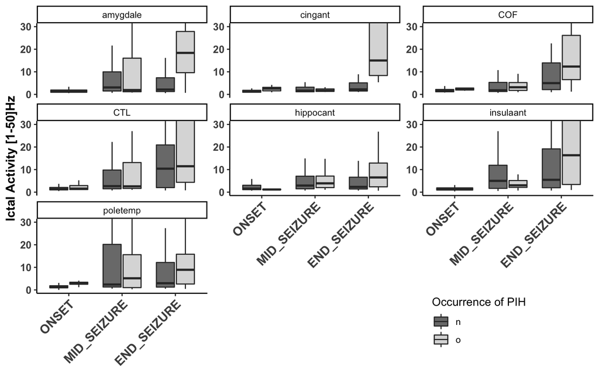

```r
datas.TF %>%
  ggplot(aes(x = Win, y = Mesure_pos, fill = Desat_Win)) +
  geom_boxplot(alpha = 0.7, outlier.shape = NA) +
  facet_wrap(~Structure, scales = "free_y") +
  scale_fill_grey() +
  theme_classic() +
  coord_cartesian(ylim=c(-0, 30)) +
  theme(legend.direction = "vertical",
        legend.box = "horizontal",
        legend.position = c(0.7,0.01),
        legend.justification = c(0, 1),
        axis.title.x = element_blank(),
        axis.title.y = element_text(size = 12, face = "bold"),
        axis.text.x = element_text(face = "bold", size = 12, angle = 45, hjust = 1),
        axis.text.y = element_text(face = "bold", size = 10, angle = 0, hjust = 1)) +
  labs(fill = "Occurrence of PIH",
       x = "",
       y = "Ictal Activity [1-50]Hz")
```

## Stat

### Model

Here we use afex package to fit power according to 3 fixed factor and Subject factor as random.  
Power is gamma distribution with log link.  
LRT is used compute pValues.

This is very time consuming so we use a parallel computing.

```r
load(file = "/Users/romain/Study/Rheins/Desaturation_Coherence/Scripts/models_TF_gamma_V07.Rdata")

# require(parallel)
# (nc <- detectCores()) # number of cores
# cl <- makeCluster(rep("localhost", nc)) # make cluster
# clusterEvalQ(cl, library(optimx)) # need to load optimx in cluster


# mixed.TF.04.g <- mixed(Mesure_pos ~ (Structure + Win + Desat_Win)^3 + ( 1| Subject),
#                        data = datas.TF,
#                        family = Gamma(link = "log"),
#                        method = "LRT",
#                        verbose = FALSE,
#                        all_fit = FALSE,
#                        expand_re = TRUE,
#                        cl = cl)



#
#  save(mixed.TF.04.g,
#       file = "/Volumes/Backup DD/From_BAIE/Rheins/Desaturation_Coherence/Scripts/models_TF_gamma_V07.Rdata")
```

```r
anova(mixed.TF.04.g)
```

```
## Mixed Model Anova Table (Type 3 tests, LRT-method)
##
## Model: Mesure_pos ~ (Structure + Win + Desat_Win)^3 + (1 | Subject)
## Data: datas.TF
## Df full model: 42
##                         Df   Chisq Chi Df Pr(>Chisq)
## Structure               38  67.068      4  9.432e-14 ***
## Win                     42   0.000      0          1
## Desat_Win               42   0.000      0          1
## Structure:Win           32 394.941     10  < 2.2e-16 ***
## Structure:Desat_Win     38  46.587      4  1.859e-09 ***
## Win:Desat_Win           42   0.000      0          1
## Structure:Win:Desat_Win 32 106.036     10  < 2.2e-16 ***
## ---
## Signif. codes:  0 '***' 0.001 '**' 0.01 '*' 0.05 '.' 0.1 ' ' 1
```

We find a 3 way interaction.

### Post-Hoc

Here we interest only on **Desat_Win:Win:Structure**.

```r
PH.emmeans <- emmeans(mixed.TF.04.g, c("Desat_Win", "Win"),
                      by = c("Structure"))

des_cont <- list("Onset_O_N" =       c(-1, 1, 0, 0, 0, 0),
                 "MID_SEIZURE_O_N" = c(0, 0, -1, 1, 0, 0),
                 "END_SEIZURE_O_N" = c(0, 0, 0, 0, -1, 1))

test(contrast(regrid(PH.emmeans), des_cont, adjust = "FDR"), side = ">")
```

```
## Structure = COF:
##  contrast         estimate    SE  df z.ratio p.value
##  Onset_O_N        0.383963 0.646 Inf   0.595  0.2760
##  MID_SEIZURE_O_N  0.903400 0.774 Inf   1.167  0.2740
##  END_SEIZURE_O_N  1.234401 1.364 Inf   0.905  0.2740
##
## Structure = CTL:
##  contrast         estimate    SE  df z.ratio p.value
##  Onset_O_N       -0.000352 0.522 Inf  -0.001  0.5003
##  MID_SEIZURE_O_N  0.592929 0.656 Inf   0.904  0.2745
##  END_SEIZURE_O_N 11.571096 2.372 Inf   4.879  <.0001
##
## Structure = amygdale:
##  contrast         estimate    SE  df z.ratio p.value
##  Onset_O_N          nonEst    NA  NA      NA      NA
##  MID_SEIZURE_O_N  3.612462 0.897 Inf   4.027  <.0001
##  END_SEIZURE_O_N 10.236036 1.825 Inf   5.608  <.0001
##
## Structure = cingant:
##  contrast         estimate    SE  df z.ratio p.value
##  Onset_O_N       -0.043892 0.603 Inf  -0.073  0.5290
##  MID_SEIZURE_O_N  0.376401 0.661 Inf   0.569  0.4269
##  END_SEIZURE_O_N 28.370948 6.587 Inf   4.307  <.0001
##
## Structure = hippocant:
##  contrast         estimate    SE  df z.ratio p.value
##  Onset_O_N       -1.766215 0.397 Inf  -4.448  1.0000
##  MID_SEIZURE_O_N -2.130078 0.602 Inf  -3.536  1.0000
##  END_SEIZURE_O_N  1.769271 0.534 Inf   3.313  0.0014
##
## Structure = insulaant:
##  contrast         estimate    SE  df z.ratio p.value
##  Onset_O_N          nonEst    NA  NA      NA      NA
##  MID_SEIZURE_O_N  2.031897 0.849 Inf   2.393  0.0251
##  END_SEIZURE_O_N -0.924094 1.026 Inf  -0.900  1.0000
##
## Structure = poletemp:
##  contrast         estimate    SE  df z.ratio p.value
##  Onset_O_N        1.134058 0.799 Inf   1.420  0.1167
##  MID_SEIZURE_O_N  0.413304 0.793 Inf   0.521  0.3011
##  END_SEIZURE_O_N  4.188534 0.959 Inf   4.367  <.0001
##
## P value adjustment: fdr method for 3 tests
## P values are right-tailed
```

To explore behaviour estimate effects.

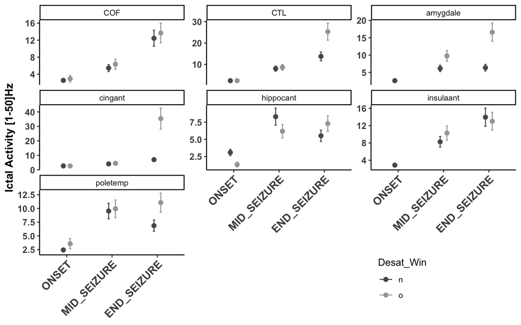

```r
emmip(mixed.TF.04.g,
      Desat_Win ~ Win|Structure,
      cov.reduce = FALSE,
      type = "response")-> p


pd <- position_dodge(0.3)

p$data %>%
  ggplot(aes(x = xvar, y = yvar, color = Desat_Win)) +
  facet_wrap(~Structure, scales = "free_y") +
  geom_errorbar(aes(ymin = yvar-SE, ymax = yvar+SE),
                  width = .1, position = pd) +
  geom_point(position = pd, size = 2) +
  scale_colour_grey(start = 0.35,
                    end = 0.65) +
  theme_classic() +
  theme(legend.direction = "vertical",
        legend.box = "horizontal",
        legend.position = c(0.7,0.01),
        legend.justification = c(0, 1),
        axis.title.x = element_blank(),
        axis.title.y = element_text(size = 12, face = "bold"),
        axis.text.x = element_text(face = "bold", size = 12, angle = 45, hjust = 1),
        axis.text.y = element_text(face = "bold", size = 10, angle = 0, hjust = 1)) +
  labs(fill = "Occurrence of PIH",
       x = "",
       y = "Ictal Activity [1-50]Hz")
```

# Connectivity

## Load datas

```r
filename.Desat <- "/Users/romain/Study/Rheins/Desaturation_Coherence/Datas_preprocessed/Mesures/Desat_parametres.txt"
datas.Desat <- read.table(filename.Desat, header = TRUE)

filename.Connect <- "/Users/romain/Study/Rheins/Desaturation_Coherence/Datas_preprocessed/Mesures/extract_tf_sample_TF_sampl_corrige_doubleCrise_Connect.txt"
datas.Connect <- read.table(filename.Connect, header = TRUE)

datas.Connect %>%
  filter(Win != "BASELINE" & Win != "pre-ONSET" & Win != "ONSET" & Win != "POST_SEIZURE") %>%
  mutate(Win = factor(Win, levels = c("MID_SEIZURE", "END_SEIZURE"))) %>%
  unique()  %>%
  mutate(Structure = case_when(Structure == "COF-amygdale" |
                                 Structure == "cingant-amygdale" |
                                 Structure == "frontallat-amygdale" ~ "Frontal - Amygdale",
                               Structure == "COF-hippocant" |
                                 Structure == "cingant-hippocant" |
                                 Structure == "frontallat-hippocant" ~ "Frontal - Hippo",
                               Structure == "COF-CTL" |
                                 Structure == "cingant-CTL" |
                                 Structure == "frontallat-CTL" ~ "Frontal - Temp_Lat",
                               Structure == "COF-insulaant" |
                                 Structure == "cingant-insulaant" |
                                 Structure == "frontallat-insulaant" ~ "Frontal - Insula",
                               Structure == "COF-poletemp" |
                                 Structure == "cingant-poletemp" |
                                 Structure == "frontallat-poletemp" ~ "Frontal - Pole",
                               Structure == "amygdale-CTL" ~ "Amygdale - Temp_Lat",
                               Structure == "hippocant-CTL" ~ "Hippo - Temp_Lat",
                               Structure == "insulaant-CTL" ~ "Insula - Temp_Lat",
                               Structure == "amygdale-insulaant" ~ "Amygdale - Insula",
                               Structure == "amygdale-hippocant" ~ "Amygdale - Hippo",
                               Structure == "hippocant-insulaant" ~ "Hippo - Insula",
                               Structure == "amygdale-poletemp" ~ "Amygdale - Pole",
                               Structure == "hippocant-poletemp" ~ "Hippo - Pole",
                               Structure == "CTL-poletemp" ~ "Temp_Lat - Pole",
                               Structure == "insulaant-poletemp" ~ "Insula - Pole"))  %>%
  mutate(Structure = as.factor(Structure)) %>%
  filter(Structure == "Frontal - Amygdale" |
         Structure == "Frontal - Hippo" |
         Structure == "Frontal - Temp_Lat" |
         Structure == "Frontal - Insula" |
         Structure == "Frontal - Pole" |
         Structure == "Amygdale - Temp_Lat" |
         Structure == "Hippo - Temp_Lat" |
         Structure == "Insula - Temp_Lat" |
         Structure == "Amygdale - Insula" |
         Structure == "Amygdale - Hippo" |
         Structure == "Hippo - Insula" |
         Structure == "Amygdale - Pole" |
         Structure == "Hippo - Pole" |
         Structure == "Temp_Lat - Pole" |
         Structure == "Insula - Pole") %>%
  na.omit(Mesure) -> datas.Connect.Clust



datas.Desat %>%
  dplyr::select(-desat) %>%
  right_join(datas.Connect.Clust) %>%
  mutate(Desat_Win = case_when(is.na(onset_desat) ~"n",
                               Win == "MID_SEIZURE" & mid_desat == "Y" ~ "o",
                               Win == "MID_SEIZURE" & mid_desat == "N" ~ "n",
                               Win == "END_SEIZURE" & end_desat == "Y" ~ "o",
                               Win == "END_SEIZURE" & end_desat == "N" ~ "n")) %>%
  mutate(Desat_Win = as.factor(Desat_Win)) %>%
  filter(Bd_Freq == "broadband") %>%
  dplyr::select(-duree_desat, -nadir_desat, -duree_crise, -mid_sz_onset,
                -mid_desat, -onset_desat.1, -end_desat, -post_desat,
                -onset_desat, -Desat, -Bd_Freq)  -> datas.Conn
rm(datas.Connect.Clust, datas.Desat)

datas.Conn %>%
    dplyr::select(-Subject) %>%
    gtsummary::tbl_strata(strata = Structure,
               .tbl_fun = ~ .x %>%
                         gtsummary::tbl_summary(by = Desat_Win, missing = "no") %>%
                         gtsummary::add_n(),
               .header = "**{strata}**"
              )
```

| **Characteristic** | **Amygdale - Hippo** **N** | **Amygdale - Hippo** **n**, N = 42<sup>1</sup> | **Amygdale - Hippo** **o**, N = 16<sup>1</sup> | **Amygdale - Insula** **N** | **Amygdale - Insula** **n**, N = 33<sup>1</sup> | **Amygdale - Insula** **o**, N = 15<sup>1</sup> | **Amygdale - Pole** **N** | **Amygdale - Pole** **n**, N = 40<sup>1</sup> | **Amygdale - Pole** **o**, N = 14<sup>1</sup> | **Amygdale - Temp_Lat** **N** | **Amygdale - Temp_Lat** **n**, N = 39<sup>1</sup> | **Amygdale - Temp_Lat** **o**, N = 15<sup>1</sup> | **Frontal - Amygdale** **N** | **Frontal - Amygdale** **n**, N = 63<sup>1</sup> | **Frontal - Amygdale** **o**, N = 13<sup>1</sup> | **Frontal - Hippo** **N** | **Frontal - Hippo** **n**, N = 67<sup>1</sup> | **Frontal - Hippo** **o**, N = 17<sup>1</sup> | **Frontal - Insula** **N** | **Frontal - Insula** **n**, N = 61<sup>1</sup> | **Frontal - Insula** **o**, N = 13<sup>1</sup> | **Frontal - Pole** **N** | **Frontal - Pole** **n**, N = 69<sup>1</sup> | **Frontal - Pole** **o**, N = 17<sup>1</sup> | **Frontal - Temp_Lat** **N** | **Frontal - Temp_Lat** **n**, N = 71<sup>1</sup> | **Frontal - Temp_Lat** **o**, N = 15<sup>1</sup> | **Hippo - Insula** **N** | **Hippo - Insula** **n**, N = 36<sup>1</sup> | … |
| --- | --- | --- | --- | --- | --- | --- | --- | --- | --- | --- | --- | --- | --- | --- | --- | --- | --- | --- | --- | --- | --- | --- | --- | --- | --- | --- | --- | --- | --- | --- |
| Win | 58 |  |  | 48 |  |  | 54 |  |  | 54 |  |  | 76 |  |  | 84 |  |  | 74 |  |  | 86 |  |  | 86 |  |  | 52 |  | … |
| MID_SEIZURE |  | 22 (52%) | 7 (44%) |  | 17 (52%) | 7 (47%) |  | 21 (52%) | 6 (43%) |  | 20 (51%) | 7 (47%) |  | 33 (52%) | 5 (38%) |  | 35 (52%) | 7 (41%) |  | 32 (52%) | 5 (38%) |  | 36 (52%) | 7 (41%) |  | 36 (51%) | 7 (47%) |  | 19 (53%) | … |
| END_SEIZURE |  | 20 (48%) | 9 (56%) |  | 16 (48%) | 8 (53%) |  | 19 (48%) | 8 (57%) |  | 19 (49%) | 8 (53%) |  | 30 (48%) | 8 (62%) |  | 32 (48%) | 10 (59%) |  | 29 (48%) | 8 (62%) |  | 33 (48%) | 10 (59%) |  | 35 (49%) | 8 (53%) |  | 17 (47%) | … |
| Mesure | 58 | 0.04 (0.02, 0.07) | 0.05 (0.04, 0.08) | 48 | 0.017 (0.003, 0.033) | 0.036 (0.006, 0.059) | 54 | 0.018 (0.005, 0.035) | 0.025 (0.006, 0.073) | 54 | 0.007 (0.001, 0.024) | 0.028 (0.018, 0.078) | 76 | 0.007 (0.000, 0.018) | 0.014 (0.011, 0.021) | 84 | 0.005 (0.000, 0.010) | 0.004 (0.001, 0.008) | 74 | 0.009 (0.001, 0.024) | 0.048 (0.012, 0.054) | 86 | 0.009 (0.001, 0.030) | 0.005 (0.001, 0.015) | 86 | 0.008 (0.002, 0.025) | 0.015 (0.008, 0.029) | 52 | 0.015 (0.006, 0.032) | … |

<sup>1</sup> n (%); Median (IQR)

## Display

To explore behaviour raw datas.

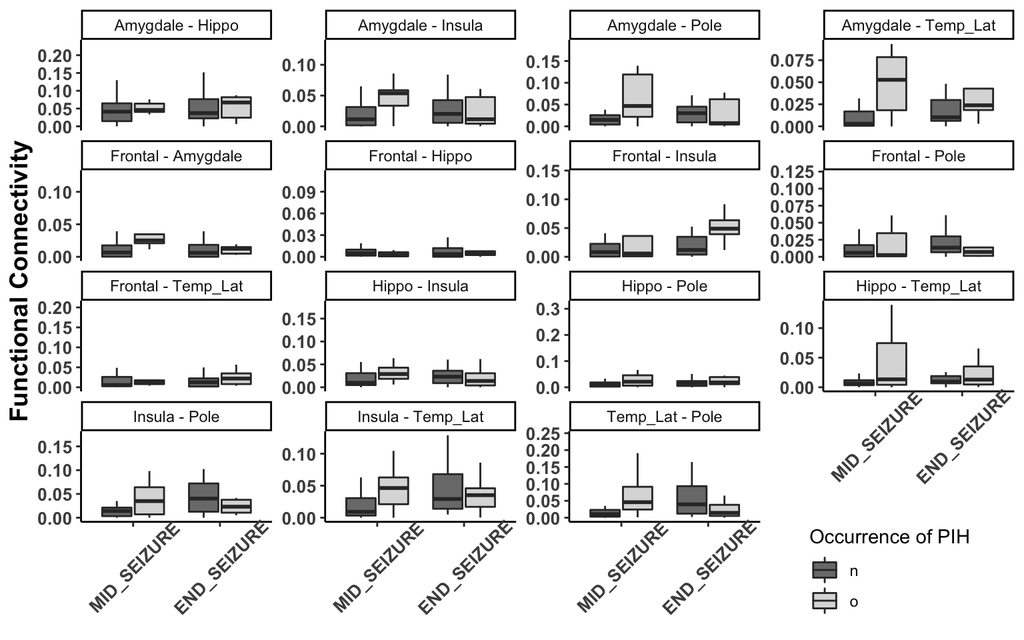

```r
datas.Conn %>%
  ggplot(aes(x = Win, y = Mesure, fill = Desat_Win)) +
  geom_boxplot(alpha = 0.7, outlier.shape = NA) +
  facet_wrap(~Structure, scales = "free_y") +
  scale_fill_grey() +
  theme_classic() +
  theme(legend.direction = "vertical",
        legend.box = "horizontal",
        legend.position = c(0.77,0.01),
        legend.justification = c(0, 1),
        axis.title.x = element_blank(),
        axis.title.y = element_text(size = 14, face = "bold"),
        axis.text.x = element_text(face = "bold", size = 10, angle = 45, hjust = 0.5, vjust = 0.65),
        axis.text.y = element_text(face = "bold", size = 10, angle = 0, hjust = 1)) +
  labs(fill = "Occurrence of PIH",
       x = "",
       y = "Functional Connectivity")
```

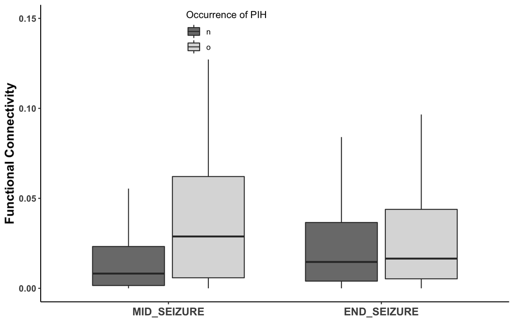

```r
datas.Conn %>%
  ggplot(aes(x = Win, y = Mesure, fill = Desat_Win)) +
  geom_boxplot(alpha = 0.7, outlier.shape = NA) +
  scale_fill_grey() +
  theme_classic() +
  coord_cartesian(ylim=c(0, 0.15)) +
  theme(legend.direction = "vertical",
        legend.box = "horizontal",
        legend.position = c(0.3,1),
        legend.justification = c(0, 1),
        axis.title.x = element_blank(),
        axis.title.y = element_text(size = 14, face = "bold"),
        axis.text.x = element_text(face = "bold", size = 12, angle = 0, hjust = 0.5, vjust = 0.5),
        axis.text.y = element_text(face = "bold", size = 10, angle = 0, hjust = 1)) +
  labs(fill = "Occurrence of PIH",
       x = "",
       y = "Functional Connectivity")
```

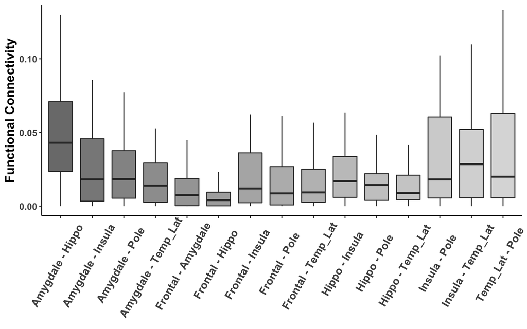

```r
datas.Conn %>%
  ggplot(aes(x = Structure, y = Mesure, fill = Structure)) +
  geom_boxplot(alpha = 0.7, outlier.shape = NA) +
  scale_fill_grey() +
  theme_classic() +
  coord_cartesian(ylim=c(0, 0.13)) +
  theme(legend.position = "none",
        axis.title.x = element_blank(),
        axis.title.y = element_text(size = 14, face = "bold"),
        axis.text.x = element_text(face = "bold", size = 12, angle = 60, hjust = 0.6, vjust = 0.65),
        axis.text.y = element_text(face = "bold", size = 10, angle = 0, hjust = 1)) +
  labs(fill = "Occurrence of PIH",
       x = "",
       y = "Functional Connectivity")
```

## Stat

### Model

Here we use afex package to fit connectivity according to 3 fixed factors and 2 random factors.  
Power is gamma distribution with log link.  
LRT is used compute pValues.

This is very time consuming so we use a parallel computing.

```r
load(file = "/Users/romain/Study/Rheins/Desaturation_Coherence/Scripts/Model_Conn_V03_Broad.RData")

#
# require(parallel)
# (nc <- detectCores()) # number of cores
# cl <- makeCluster(rep("localhost", nc)) # make cluster
# clusterEvalQ(cl, library(optimx)) # need to load optimx in cluster

# mixed.Con.03 <- mixed(Mesure+0.0001 ~ (Desat_Win + Structure + Win)^3 + (1|Subject) + (1|Structure),
#                       family = Gamma(link = "log"),
#                       data = datas.Broad,
#                       method = "LRT",
#                       verbose = FALSE)
#plot(simulateResiduals(fittedModel = mixed.Con.03$full_model, n = 1000))

anova(mixed.Con.03)
```

```
## Mixed Model Anova Table (Type 3 tests, LRT-method)
##
## Model: Mesure + 1e-04 ~ (Desat_Win + Structure + Win)^3 + (1 | Subject) +
## Model:     (1 | Structure)
## Data: datas.Broad
## Df full model: 63
##                         Df   Chisq Chi Df Pr(>Chisq)
## Desat_Win               62  0.4496      1   0.502541
## Structure               49 44.0887     14  5.728e-05 ***
## Win                     62  0.6244      1   0.429408
## Desat_Win:Structure     49 14.1102     14   0.441533
## Desat_Win:Win           62 10.4655      1   0.001216 **
## Structure:Win           49  8.6268     14   0.854191
## Desat_Win:Structure:Win 49  7.6632     14   0.906126
## ---
## Signif. codes:  0 '***' 0.001 '**' 0.01 '*' 0.05 '.' 0.1 ' ' 1
```

### Post-Hoc

```r
PH.emmeans <- emmeans(mixed.Con.03, c("Desat_Win"), by = "Win")
```

```
## NOTE: Results may be misleading due to involvement in interactions
```

```r
des_cont <- list("O-N" = c(-1, 1))
test(contrast(regrid(PH.emmeans), des_cont, adjust = "FDR"), side = "both")
```

```
## Win = MID_SEIZURE:
##  contrast estimate      SE  df z.ratio p.value
##  O-N       0.00999 0.00490 Inf   2.040  0.0414
##
## Win = END_SEIZURE:
##  contrast estimate      SE  df z.ratio p.value
##  O-N      -0.00636 0.00386 Inf  -1.648  0.0993
##
## Results are averaged over the levels of: Structure
```

```r
emmip(mixed.Con.03,
      Desat_Win ~ Win,
      cov.reduce = FALSE,
      type = "response") -> p.01
```

```
## NOTE: Results may be misleading due to involvement in interactions
```

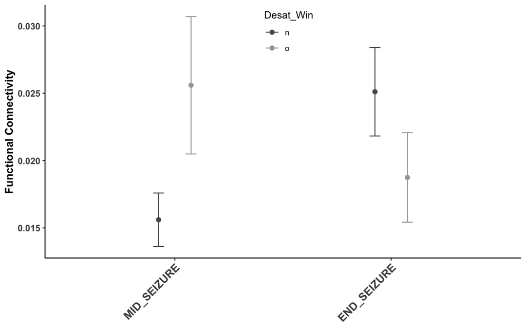

```r
p.01$data %>%
  ggplot(aes(x = Win, y = yvar, color = Desat_Win)) +
  geom_errorbar(aes(ymin = yvar-SE, ymax = yvar+SE),
                  width = .1, position = pd) +
  geom_point(position = pd, size = 2) +
  scale_colour_grey(start = 0.35,
                    end = 0.65) +
  theme_classic() +
  theme(legend.direction = "vertical",
        legend.box = "horizontal",
        legend.position = c(0.45,1),
        legend.justification = c(0, 1),
        axis.title.x = element_blank(),
        axis.title.y = element_text(size = 12, face = "bold"),
        axis.text.x = element_text(face = "bold", size = 12, angle = 45, hjust = 1),
        axis.text.y = element_text(face = "bold", size = 10, angle = 0, hjust = 1)) +
  labs(fill = "Occurrence of PIH",
       x = "",
       y = "Functional Connectivity")
```

```r
PH.emmeans <- emmeans(mixed.Con.03, c("Structure"), type = "response")
```

```
## NOTE: Results may be misleading due to involvement in interactions
```

```r
test(contrast(pairs(PH.emmeans), adjust = "FDR"), side = "both")[,c(1:3, 7)] %>%
  filter(p.value < 0.05) %>%
  mutate(ratio = round(ratio, 3),
         SE       = round(SE, 3),
         p.value  = round(p.value, 6))
```

```
##                                               contrast ratio    SE  p.value
## 1    ((Amygdale / Hippo) / (Amygdale / Insula)) effect 2.198 0.591 0.014786
## 2  ((Amygdale / Hippo) / (Amygdale / Temp_Lat)) effect 2.508 0.645 0.002671
## 3   ((Amygdale / Hippo) / (Frontal / Amygdale)) effect 3.246 0.864 0.000203
## 4      ((Amygdale / Hippo) / (Frontal / Hippo)) effect 5.755 1.428 0.000000
## 5     ((Amygdale / Hippo) / (Frontal / Insula)) effect 2.284 0.596 0.007802
## 6       ((Amygdale / Hippo) / (Frontal / Pole)) effect 3.229 0.786 0.000051
## 7   ((Amygdale / Hippo) / (Frontal / Temp_Lat)) effect 2.449 0.602 0.002671
## 8       ((Amygdale / Hippo) / (Hippo / Insula)) effect 2.385 0.576 0.002671
## 9         ((Amygdale / Hippo) / (Hippo / Pole)) effect 2.277 0.538 0.003252
## 10    ((Amygdale / Hippo) / (Hippo / Temp_Lat)) effect 2.961 0.679 0.000057
## 11       ((Amygdale / Hippo) / (Insula / Pole)) effect 1.946 0.472 0.024608
## 12   ((Amygdale / Hippo) / (Insula / Temp_Lat)) effect 2.006 0.474 0.014581
## 13    ((Amygdale / Insula) / (Frontal / Hippo)) effect 2.608 0.690 0.002671
## 14      ((Amygdale / Pole) / (Frontal / Hippo)) effect 3.177 0.840 0.000216
## 15  ((Amygdale / Temp_Lat) / (Frontal / Hippo)) effect 2.286 0.597 0.007802
## 16   ((Frontal / Amygdale) / (Temp_Lat / Pole)) effect 0.434 0.108 0.004321
## 17     ((Frontal / Hippo) / (Frontal / Insula)) effect 0.395 0.103 0.002671
## 18   ((Frontal / Hippo) / (Frontal / Temp_Lat)) effect 0.424 0.102 0.002671
## 19       ((Frontal / Hippo) / (Hippo / Insula)) effect 0.413 0.107 0.003558
## 20         ((Frontal / Hippo) / (Hippo / Pole)) effect 0.394 0.098 0.002113
## 21     ((Frontal / Hippo) / (Hippo / Temp_Lat)) effect 0.513 0.124 0.024108
## 22        ((Frontal / Hippo) / (Insula / Pole)) effect 0.337 0.086 0.000312
## 23    ((Frontal / Hippo) / (Insula / Temp_Lat)) effect 0.347 0.087 0.000323
## 24      ((Frontal / Hippo) / (Temp_Lat / Pole)) effect 0.245 0.058 0.000000
## 25       ((Frontal / Pole) / (Temp_Lat / Pole)) effect 0.437 0.104 0.003301
## 26     ((Hippo / Temp_Lat) / (Temp_Lat / Pole)) effect 0.476 0.118 0.013644
```

```r
emmip(mixed.Con.03,
      ~ Structure,
      cov.reduce = FALSE,
      type = "response") -> p.00
```

```
## NOTE: Results may be misleading due to involvement in interactions
```

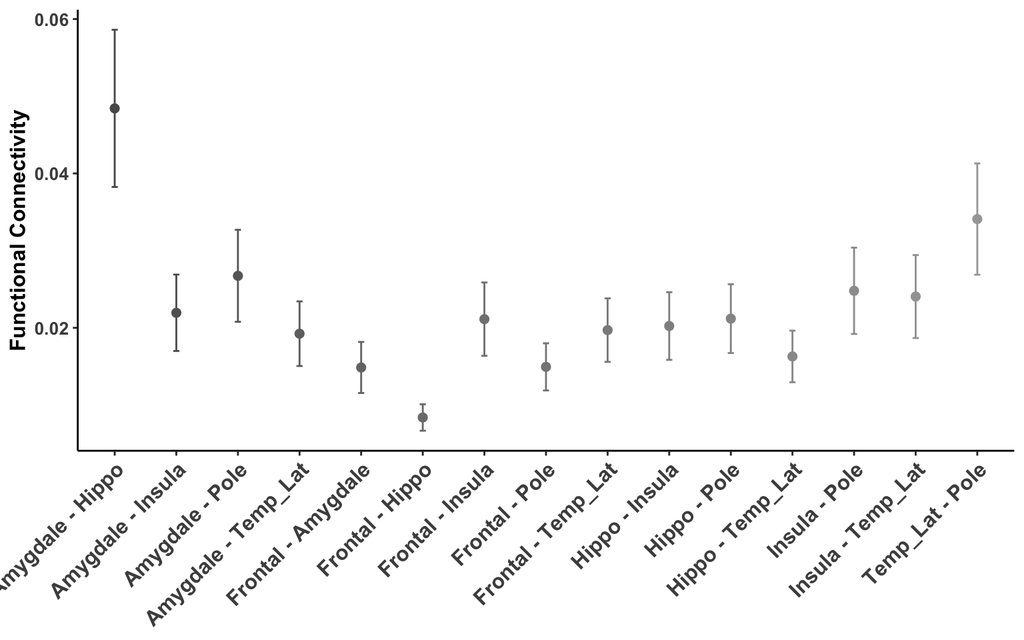

```r
p.00$data %>%
  ggplot(aes(x = Structure, y = yvar, color = Structure)) +
  geom_errorbar(aes(ymin = yvar-SE, ymax = yvar+SE),
                  width = .1, position = pd) +
  geom_point(position = pd, size = 2) +
  scale_colour_grey(start = 0.35,
                    end = 0.65) +
  theme_classic() +
  theme(legend.position = "none",
        axis.title.x = element_blank(),
        axis.title.y = element_text(size = 12, face = "bold"),
        axis.text.x = element_text(face = "bold", size = 12, angle = 45, hjust = 1),
        axis.text.y = element_text(face = "bold", size = 10, angle = 0, hjust = 1)) +
  labs(fill = "Structure",
       x = "",
       y = "Functional Connectivity")
```

# Nadir

## Load datas

```r
filename.TF <- "/Users/romain/Study/Rheins/Desaturation_Coherence/Datas_preprocessed/Mesures/extract_tf_sample_TF_sampl_corrige_doubleCrise_TF_sampl.txt"

filename.Desat <- "/Users/romain/Study/Rheins/Desaturation_Coherence/Datas_preprocessed/Mesures/Desat_parametres.txt"

datas.TF    <- read.table(filename.TF, header = TRUE)
datas.Desat <- read.table(filename.Desat, header = TRUE)


datas.TF %>%
  filter(Desat == "o") %>%
  filter(Win != "BASELINE" & Win != "pre_ONSET" & Win!= "POST_SEIZURE") %>%
  filter(Structure != "frontallat" & Structure != "insulapost" & Structure != "hippocpost") %>%
  mutate(Win = factor(Win, levels = c("ONSET", "MID_SEIZURE", "END_SEIZURE"))) %>%
  drop_na(Mesure) %>%
  mutate(Desat = Desat,
         Mesure_log = log(0.001 + Mesure + abs(min(Mesure))),
         Mesure_pos = 0.001 + Mesure + abs(min(Mesure))) -> datas.TF


datas.Desat %>%
  dplyr::select(-desat) %>%
  right_join(datas.TF) %>%
  filter(Win != "BASELINE", Win != "pre_ONSET") %>%
  mutate(Desat_Win = case_when(is.na(onset_desat) ~"n",
                               Win == "pre_ONSET" & onset_desat <= 0 ~ "o",
                               Win == "pre_ONSET" & onset_desat > 0 ~ "n",
                               Win == "ONSET" & onset_desat.1 == "Y" ~ "o",
                               Win == "ONSET" & onset_desat.1 == "N" ~ "n",
                               Win == "MID_SEIZURE" & mid_desat == "Y" ~ "o",
                               Win == "MID_SEIZURE" & mid_desat == "N" ~ "n",
                               Win == "END_SEIZURE" & end_desat == "Y" ~ "o",
                               Win == "END_SEIZURE" & end_desat == "N" ~ "n",
                               Win == "POST_SEIZURE" & post_desat == "Y" ~ "o",
                               Win == "POST_SEIZURE" & post_desat == "N" ~ "n"),
         nadir_desat = 100-nadir_desat) %>%
  mutate(Desat_Win = as.factor(Desat_Win)) %>%
  dplyr::select(-fin, -EI,
                -duree_crise, -mid_sz_onset,
                -mid_desat, -onset_desat.1, -end_desat, -post_desat) %>%
  droplevels()-> datas.TF
datas.TF %>%
  mutate(Structure = case_when(Structure == "hippocant" ~ "Ant Hippo",
                               Structure == "amygdale" ~ "Amygdala",
                               Structure == "cingant" ~ "ACC",
                               Structure == "insulaant" ~ "Ant Insula",
                               Structure == "CTL" ~ "Lat Temp",
                               Structure == "COF" ~ "OFC",
                               Structure == "poletemp" ~ "Pole Temp"),
         Win = case_when(Win == "ONSET" ~ "Onset",
                         Win == "MID_SEIZURE" ~ "Propagation",
                         Win == "END_SEIZURE" ~ "End")) %>%
   mutate(Structure = factor(Structure, levels = c("Ant Hippo", "Amygdala", "Pole Temp", "Lat Temp", "Ant Insula", "OFC", "ACC")),
           Win = factor(Win, levels = c("Onset", "Propagation", "End"))) %>%
  mutate(Structure = as.factor(Structure)) %>%
  data.frame() -> datas.TF


rm(datas.Desat)


datas.TF %>%
  dplyr::select(-Subject, -onset_desat, -duree_desat, -Desat, -Mesure, -Mesure_log, -Desat_Win) %>%
  gtsummary::tbl_summary(by = "Structure") %>%
  gtsummary::add_p()
```

| **Characteristic** | **Ant Hippo**, N = 1,530<sup>1</sup> | **Amygdala**, N = 1,290<sup>1</sup> | **Pole Temp**, N = 1,440<sup>1</sup> | **Lat Temp**, N = 1,470<sup>1</sup> | **Ant Insula**, N = 1,200<sup>1</sup> | **OFC**, N = 810<sup>1</sup> | **ACC**, N = 420<sup>1</sup> | **p-value**<sup>2</sup> |
| --- | --- | --- | --- | --- | --- | --- | --- | --- |
| nadir_desat | 18 (13, 21) | 18 (14, 20) | 19 (14, 21) | 18 (12, 21) | 17 (13, 20) | 17 (13, 20) | 17 (16, 20) | <0.001 |
| Unknown | 180 | 180 | 180 | 180 | 90 | 180 | 180 |  |
| Win |  |  |  |  |  |  |  | >0.9 |
| Onset | 510 (33%) | 430 (33%) | 480 (33%) | 490 (33%) | 400 (33%) | 270 (33%) | 140 (33%) |  |
| Propagation | 510 (33%) | 430 (33%) | 480 (33%) | 490 (33%) | 400 (33%) | 270 (33%) | 140 (33%) |  |
| End | 510 (33%) | 430 (33%) | 480 (33%) | 490 (33%) | 400 (33%) | 270 (33%) | 140 (33%) |  |
| Mesure_pos | 3 (1, 6) | 2 (1, 12) | 3 (1, 13) | 2 (1, 10) | 3 (1, 12) | 2 (1, 7) | 2 (1, 3) | <0.001 |

<sup>1</sup> Median (IQR); n (%)  
<sup>2</sup> Kruskal-Wallis rank sum test; Pearson's Chi-squared test

## Stat

### Model

```
## Mixed Model Anova Table (Type 3 tests, LRT-method)
##
## Model: Mesure_pos ~ (Structure + Win + nadir_desat)^3 + (1 | Subject)
## Data: datas.TF
## Df full model: 44
##                           Df    Chisq Chi Df Pr(>Chisq)
## Structure                 38 139.8049      6     <2e-16 ***
## Win                       42 213.5005      2     <2e-16 ***
## nadir_desat               43   0.7581      1     0.3839
## Structure:Win             32 218.4537     12     <2e-16 ***
## Structure:nadir_desat     38 268.5661      6     <2e-16 ***
## Win:nadir_desat           42  77.7015      2     <2e-16 ***
## Structure:Win:nadir_desat 32 272.1465     12     <2e-16 ***
## ---
## Signif. codes:  0 '***' 0.001 '**' 0.01 '*' 0.05 '.' 0.1 ' ' 1
```

### Post-Hoc

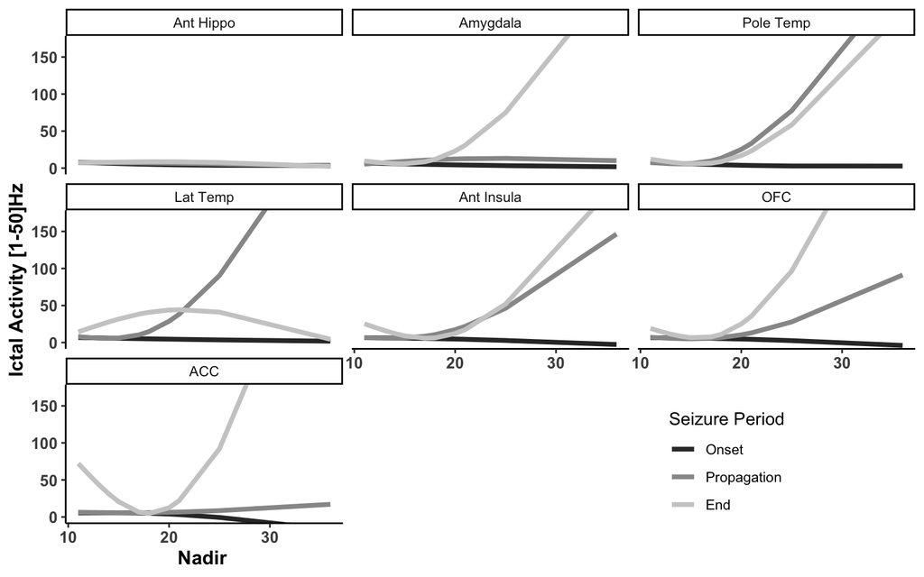

```r
load(file = "/Users/romain/Study/Rheins/Desaturation_Coherence/Article/models_nadir.Rdata")

# mixed.TF.09.g <- glmer(Mesure_pos ~ (Structure + Win + ns(nadir_desat,2))^3 +
#                                      ( 1| Subject),
#                         data = datas.TF,
#                         family = Gamma(link = "identity"))

emmip(mixed.TF.09.g,
      Win ~ nadir_desat|Structure,
      cov.reduce = FALSE) +
      scale_colour_grey() +
      theme_classic() +
  coord_cartesian(ylim =c(0, 150)) -> p

datas.TF %>%
  mutate(Desat =Desat) %>%
  ggplot(aes(x = nadir_desat, y = Mesure, color = Win, shape = Win)) +
    facet_wrap(~Structure) +
    geom_line(aes(x = xvar, y = yvar), data = p$data, size = 1.4) +
    coord_cartesian(ylim =c(0, 170)) +
    scale_colour_grey() +
    theme_classic() +
    theme(legend.direction = "vertical",
          legend.box = "horizontal",
          legend.position = c(0.7,0.25),
          legend.justification = c(0, 1),
          axis.title.x = element_text(size = 12, face = "bold", hjust = 0.14),
          axis.title.y = element_text(size = 12, face = "bold"),
          axis.text.x = element_text(face = "bold", size = 10),
          axis.text.y = element_text(face = "bold", size = 10)) +
  labs(x = "Nadir",
       y = "Ictal Activity [1-50]Hz",
       shape = "Seizure Period",
       color = "Seizure Period")
```